# Homework 5: spatial interpolation

# Dataset preparation

|  | x | y | value | altitude |
| --- | --- | --- | --- | --- |
| 0 | 6.351499 | 46.544351 | 151 | 682 |
| 1 | 6.406433 | 46.710820 | 255 | 813 |
| 2 | 6.574735 | 46.737855 | 79 | 436 |
| 3 | 6.599386 | 46.904837 | 191 | 833 |
| 4 | 6.607163 | 46.835829 | 194 | 579 |

Each line contains four values: the x-coordinate, y-coordinate, value - corresponding to possibly rainfall and an altitude of the place.

|  | x | y | value | altitude |
| --- | --- | --- | --- | --- |
| count | 100.000000 | 100.000000 | 100.000000 | 100.000000 |
| mean | 8.396067 | 46.935516 | 180.150000 | 891.540000 |
| std | 0.962098 | 0.454626 | 116.681071 | 483.655784 |
| min | 6.351499 | 46.001432 | 10.000000 | 248.000000 |
| 25% | 7.794263 | 46.530013 | 97.750000 | 516.500000 |
| 50% | 8.589010 | 46.902851 | 141.000000 | 764.000000 |
| 75% | 9.088685 | 47.359405 | 254.250000 | 1094.750000 |
| max | 10.116038 | 47.750880 | 585.000000 | 2418.000000 |

# Check if differences in training and testing parts are statistically significant

In order to verify if train and test sample are similar, I conduct 2 statistical tests: Two-sample t-test and Wilcoxon rank-sum test for each variable present in the dataset.

## Two-sample T-test

```
Two-Sample t-Test for x:
t-statistic: 2.1074
p-value: 0.0356

Two-Sample t-Test for y:
t-statistic: 0.3905
p-value: 0.6963

Two-Sample t-Test for value:
t-statistic: -0.4116
p-value: 0.6808

Two-Sample t-Test for altitude:
t-statistic: 0.9635
p-value: 0.3358
```

## Wilcoxon Rank-Sum Test

```
Mann-Whitney U Test for x:
U-statistic: 20988.0000
p-value: 0.0275

Mann-Whitney U Test for y:
U-statistic: 18725.0000
p-value: 0.7543

Mann-Whitney U Test for value:
U-statistic: 17584.0000
p-value: 0.5223

Mann-Whitney U Test for altitude:
U-statistic: 19394.0000
p-value: 0.3831
```

As we can see, apart from the x-coordinate, the differences in both datasets are not statistically significant.

# Modelling

In order to find the optimal number of neighbors for both NN and IDW methods I conduct leave-one-out crossvalidation.

## Leave-one-out crossvalidation for number of neighbors in NN and IDW

```
Optimal n_neighbors for NN: 24
Optimal n_neighbors for IDW: 98
```

The optimal setting for NN is 24 neighbors and for IDW 98 neighbors respectively (so in IDW situation almost all training samples are taken into account). Now I am ready to fit the best models and analyze their mean-squared error.

## Best NN and IDW models

```
NN MSE: 9403.57
IDW MSE: 8459.00
```

## Kriging models

I also build 2 Kriging models, Ordinary and Universal Kriging respectively.

```
Ordinary Kriging MSE: 7086.92
Universal Kriging MSE: 7026.29
```

# Plots

In this section I investigate the differences in MSE along different interploation methods. Then I analyze the heatmap showing how grid of popints is predicted by each method.

## Prepare predictions for grid of points

## MSE comparison

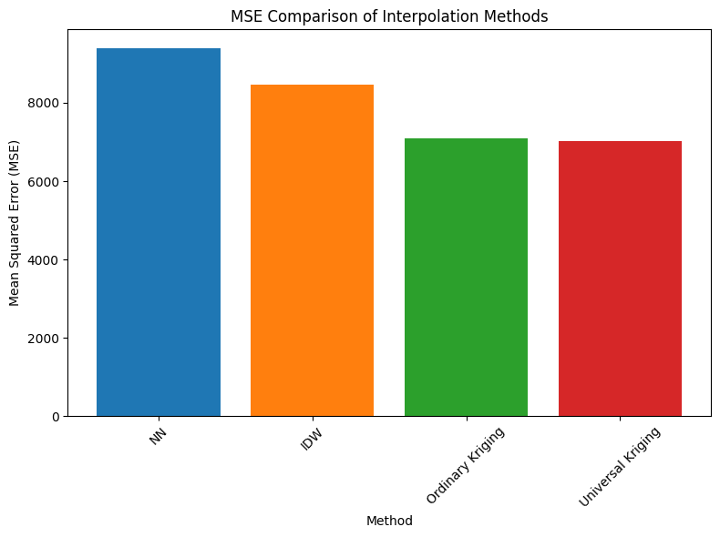

The best model appears to be Universal Kriging along with Ordinary Kriging with the lowest MSE. Methods based on nearest neighbor strategy prove to be significantly worse.

## Plot rainfall heatmaps

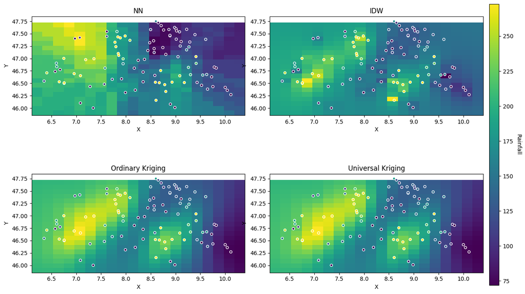